# FARMR!SK automatic report

The main pathways of disease entry are: **Animals from other origin** and **Neigbouring farms**.

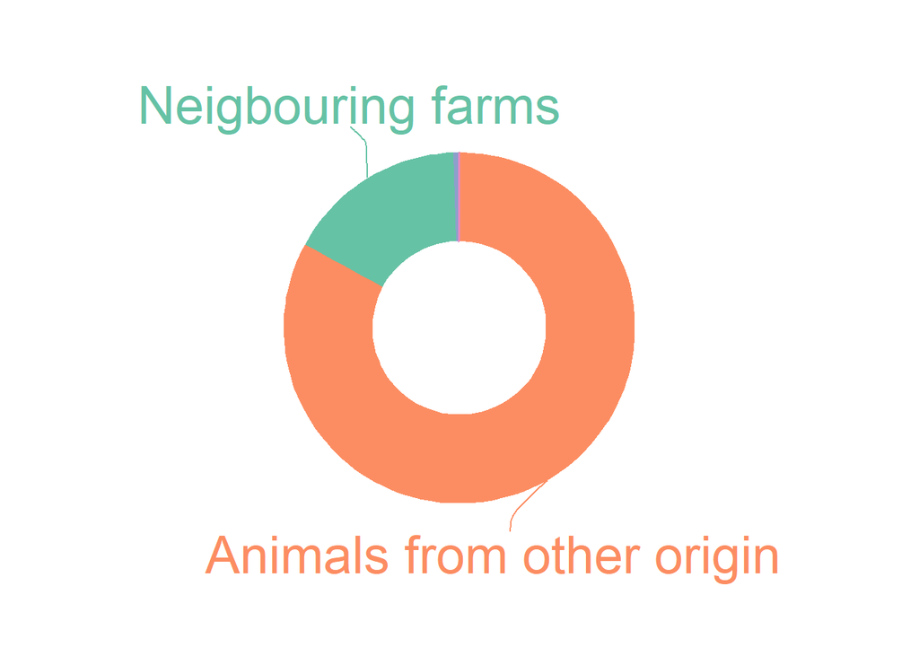

(a) IBR

[figure not shown]

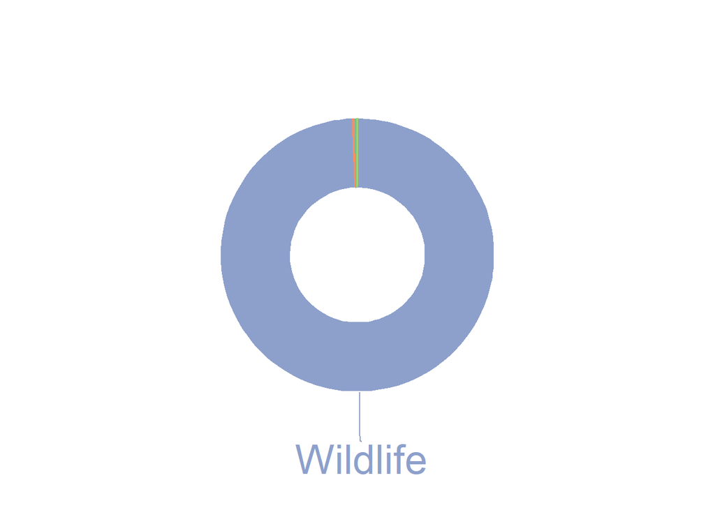

(c) TB

Figure 1.2: Risk of disease entry by pathway

## **Infectious Bovine Rhinotracheitis (IBR)**

### Current risk

Annual risk of IBR entry in the farm: **4.5%** (4.03-4.97%)

By pathway:

- Animals from other origin: **3.77%** (3.34-4.16%)
- Neigbouring farms: **0.752%** (0.555-0.969%)
- People visits to the farm: **0.0201%** (0.00567-0.0354%)
- Vehicle visits to the farm: **0.00195%** (0.000204-0.00816%)

### Risk reduction of biosecurity measures

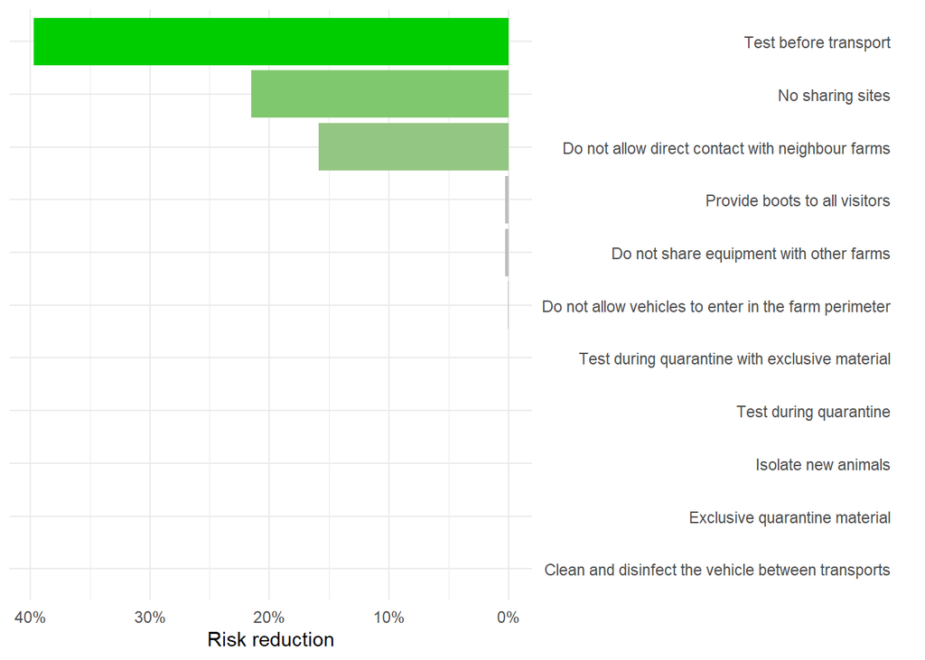

## **Bovine viral diarrhea (BVD)**

### Current risk

Annual risk of BVD entry in the farm: **27.2%** (21.9-31.1%)

By pathway:

- Animals from other origin: **15.7%** (10.8-19.5%)
- Neigbouring farms: **13.7%** (10.5-16.3%)
- People visits to the farm: **0.0316%** (0.00852-0.0761%)
- Vehicle visits to the farm: **0.00201%** (0.000109-0.0111%)

### Risk reduction of biosecurity measures

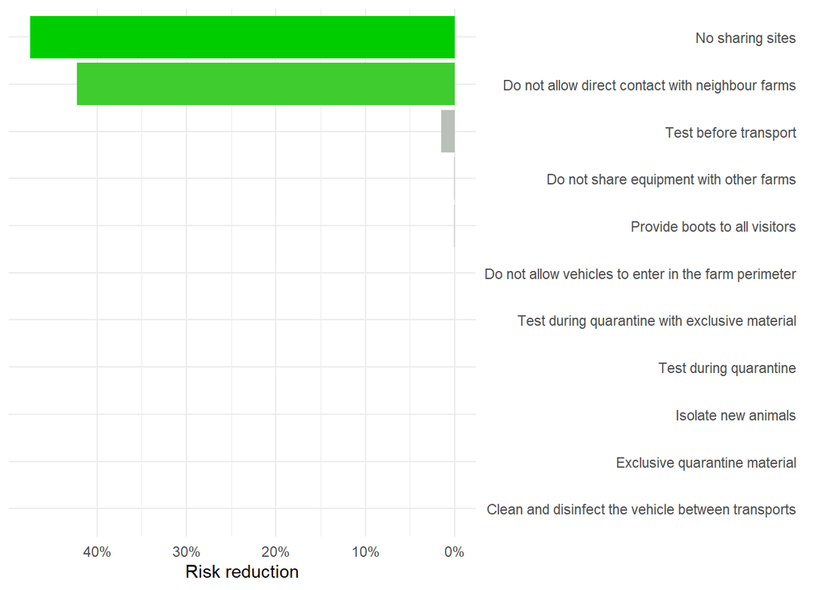

## **Bovine Tuberculosis (TB)**

### Current risk

By pathway:

- Wildlife: **0.731%** (0.335-1.56%)
- Animals from other origin: **0.00248%** (0.00193-0.00323%)
- Neigbouring farms: **0.00185%** (0.00122-0.00281%)
- People visits to the farm: **1.52e-05%** (8.33e-07-7.03e-05%)
- Vehicle visits to the farm: **1.66e-07%** (7.08e-10-4.17e-06%)

### Risk reduction of biosecurity measures

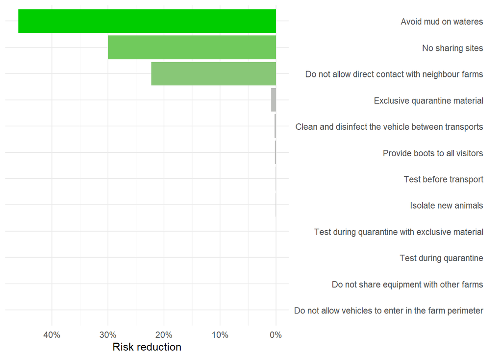

# 🐄 Description of the farm

## Farm information

**Location:** Cataluña, Spain

**Farm type:** Beef cattle, NA

**Other animals in the farm:**

- **Direct contact with cattle:** 1 dogs, 2 cats
- **No direct contact with cattle:**

**Neighbours**: 1 cattle farms within a 1-2km radious, possible direct contact (IBR: 0.752%, BVD: 13.7%, TB: 0.00185%)

## Farm vehicles

| veh_id | Size | Shared | Cleaning |
| --- | --- | --- | --- |
| gris (a) | 10m2 | No | From time to time |

## Visits

### People entering the barn

| Visit | Type | Frequency | Boots | Equipment | Risk |
| --- | --- | --- | --- | --- | --- |
| vet | External veterinarians | 6 | Always used in other farms, never cleaned and disinfected | Always used in other farms, sometimes cleaned and disinfected | IBR: 0.0201%, BVD: 0.0316%, TB: 1.52e-05% |

### Vehicles entering the farm perimeter

| Visit | Type | Frequency | Driver | Risk |
| --- | --- | --- | --- | --- |
| terneros | Calf transport vehicle | 2 | No contact with animals | IBR: 0.00142%, BVD: 0.00188%, TB: 4.11e-08% |
| cadaveres | Rendering vehicle | 1 | - | IBR: 0.000309%, BVD: 6.46e-05%, TB: 2e-08% |

# 🚚 Movements

Animal movements in the last 12 months

| mov_id | When | Origin | Animals moved | Shared site | Vehicle used | Risk |
| --- | --- | --- | --- | --- | --- | --- |
| macho_ficticio | ➡️ One-off entry: 2025-11-12 | Other farm/s: Lleida | 1 Bulls | - | Own gris | IBR: 2.76%, BVD: 0.684%, TB: 4.28e-05% |
| pasto_otonyo | 🔁 Recurrent round: 1 times/year, out for 60 days | Pasture: Lleida | 10 Calves ( <8 m), 4 Heifers (8 - 24 m), 19 Adult cows (>24 m), 1 Bulls | Shared with 20 animals from 1 farms (presence of bulls) | No | IBR: 1.03%, BVD: 15.1%, TB: 0.345% |
| pasto_llumas_verano | 🔁 Recurrent round: 1 times/year, out for 120 days | Pasture: Lleida | 10 Calves ( <8 m), 4 Heifers (8 - 24 m), 19 Adult cows (>24 m), 1 Bulls | No | No | IBR: 0%, BVD: 0%, TB: 0.345% |

### Health status and tests in origin

[output not shown]

### Quarantine

#### Characteristics

*No quarantine*

# 🐗 Wildlife

**Wildlife:** IBR: -, BVD: -, TB: 0.731%

### Farm water points

| Risk point | Mud/Organic | Risk |
| --- | --- | --- |
| 100% High waterer (>90cm) | 100% | 0.0038% (0.00041-0.016%) |

### Pasture water points

*No pasture water points*

# Comments

*No survey comments*

# Technical Annex

- Simulation date: 2025-12-02 13:12:10
- Script unification date: 2025-12-02 13:09:10
- Repository: https://github.com/NataliaCiria/biosecurity_model.git
- Last commit: 227e16341bdba07ddd3522e39e26e8cdd06448a3
- Last commit date: 2025-12-01 23:54:29
- user_id:
- farm_id: bc9_v2
- Risk timeframe: 360 days
- Calculate all summaries: FALSE
- Automatic what-if scenarios: TRUE
- Analyse model sensitivity: FALSE
- Farm biosecurity survey: _v4_3_ciria 2015-05-23
- Movements surveys:
  - v4_1_ciria ( 3 ): pasto_llumas_verano, pasto_otonyo, macho_ficticio